# STAT 540 Seminar 9: Cluster Analysis and PCA

## STAT 540 Seminar 9: Cluster Analysis and PCA

### Hao Chen

**2014-03-21**

- Load data and packages
- Sample Clustering
  - Hierarchical clustering for `photoRec` data
  - Partitioning methods for `photoRec` data
  - Exercise
- Gene clustering
- Statistical measures to evaluate clusters
- PCA (principal components analysis)

> The R markdown file can be found on my [Github](https://github.com/nelsonch/stat540-2014-chen-hao/blob/master/seminar%2009/seminar09.Rmd).

### Load data and packages

Load required packages.

```r
> library(RColorBrewer)
> library(cluster)
> library(pvclust)
> library(xtable)
> library(limma)
> library(plyr)
> library(lattice)
```

Load the `photoRec` data.

```r
> prDat <- read.table("GSE4051_data.tsv", header = TRUE, row.names = 1)
> str(prDat, max.level = 0)
```

```
'data.frame':   29949 obs. of  39 variables:
```

```r
> prDes <- readRDS("GSE4051_design.rds")
> str(prDes)
```

```
'data.frame':   39 obs. of  4 variables:
 $ sidChar : chr  "Sample_20" "Sample_21" "Sample_22" "Sample_23" ...
 $ sidNum  : num  20 21 22 23 16 17 6 24 25 26 ...
 $ devStage: Factor w/ 5 levels "E16","P2","P6",..: 1 1 1 1 1 1 1 2 2 2 ...
 $ gType   : Factor w/ 2 levels "wt","NrlKO": 1 1 1 1 2 2 2 1 1 1 ...
```

Rescale the rows

```r
> sprDat <- t(scale(t(prDat)))
> str(sprDat, max.level = 0, give.attr = FALSE)
```

```
 num [1:29949, 1:39] 0.0838 0.1758 0.7797 -0.3196 0.8358 ...
```

```r
> round(data.frame(avgBefore = rowMeans(head(prDat)),
+                  avgAfter = rowMeans(head(sprDat)),
+                  varBefore = apply(head(prDat), 1, var),
+                  varAfter = apply(head(sprDat), 1, var)), 2)
```

```
             avgBefore avgAfter varBefore varAfter
1415670_at        7.22        0      0.02        1
1415671_at        9.37        0      0.35        1
1415672_at        9.70        0      0.15        1
1415673_at        8.42        0      0.03        1
1415674_a_at      8.47        0      0.02        1
1415675_at        9.67        0      0.03        1
```

> The data for each row – which is for one probeset – now has mean 0 and variance 1.

### Sample Clustering

#### Hierarchical clustering for `photoRec` data

> For most expression data applications, we suggest you should standardize the data; use Euclidean as the “distance” (so it's just like Pearson correlation) and use “average linkage”.

```r
> # compute pairwise distances
> pr.dis <- dist(t(sprDat), method = 'euclidean')
>
> # create a new factor representing the interaction of gType and devStage
> prDes$grp <- with(prDes, interaction(gType, devStage))
> summary(prDes$grp)
```

```
       wt.E16     NrlKO.E16         wt.P2      NrlKO.P2         wt.P6
            4             3             4             4             4
     NrlKO.P6        wt.P10     NrlKO.P10    wt.4_weeks NrlKO.4_weeks
            4             4             4             4             4
```

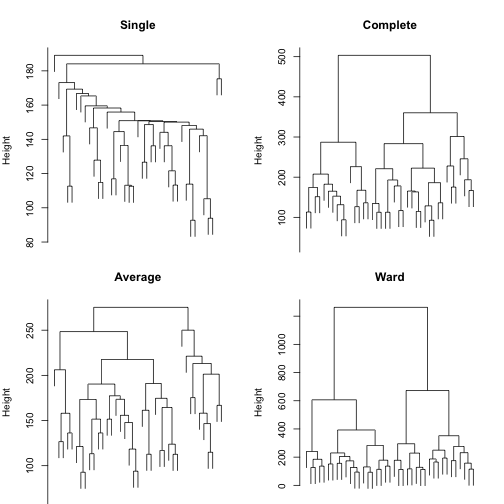

```r
>
> # compute hierarchical clustering using different linkage types
> pr.hc.s <- hclust(pr.dis, method = 'single')
> pr.hc.c <- hclust(pr.dis, method = 'complete')
> pr.hc.a <- hclust(pr.dis, method = 'average')
> pr.hc.w <- hclust(pr.dis, method = 'ward')
>
> # plot them
> op <- par(mar = c(0,4,4,2), mfrow = c(2,2))
>
> plot(pr.hc.s, labels = FALSE, main = "Single", xlab = "")
> plot(pr.hc.c, labels = FALSE, main = "Complete", xlab = "")
> plot(pr.hc.a, labels = FALSE, main = "Average", xlab = "")
> plot(pr.hc.w, labels = FALSE, main = "Ward", xlab = "")
```

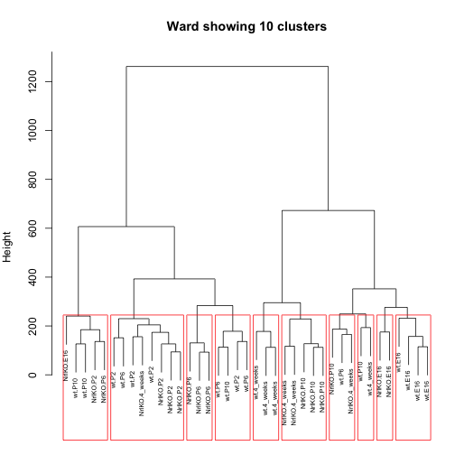

```r
> par(op)
>
> # identify 10 clusters
> op <- par(mar = c(1,4,4,1))
> plot(pr.hc.w, labels = prDes$grp, cex = 0.6, main = "Ward showing 10 clusters")
> rect.hclust(pr.hc.w, k = 10)
```

```r
> par(op)
```

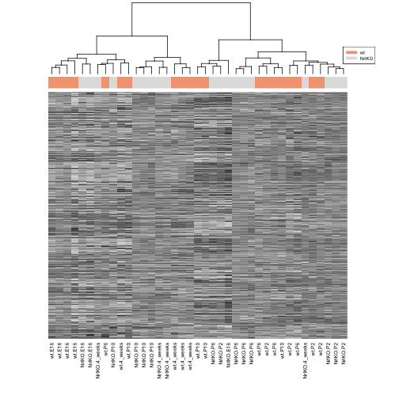

```r
> jGraysFun <- colorRampPalette(brewer.pal(n = 9, "Greys"))
> gTypeCols <- brewer.pal(11, "RdGy")[c(4,7)]
> heatmap(as.matrix(sprDat), Rowv = NA, col = jGraysFun(256),
+         hclustfun = function(x) hclust(x, method = 'ward'),
+         scale = "none", labCol = prDes$grp, labRow = NA, margins = c(8,1),
+         ColSideColor = gTypeCols[unclass(prDes$gType)])
> legend("topright", legend = levels(prDes$gType),
+        col = gTypeCols, lty = 1, lwd = 5, cex = 0.5)
```

#### Partitioning methods for `photoRec` data

#### K-means clustering

Do a clustering of samples using all genes (~30K)

```r
> set.seed(31)
> k <- 5
> pr.km <- kmeans(t(sprDat), centers = k, nstart =  50)
>
> #We can look at the within sum of squares of each cluster
> pr.km$withinss
```

[1] 120153 78227 110209 100197 133036

```r
>
> #We can look at the composition of each cluster
> pr.kmTable <- data.frame(devStage = prDes$devStage, cluster = pr.km$cluster)
> prTable  <-  xtable(with(pr.kmTable, table(devStage,cluster)),
+                     caption='Number of samples from each develomental stage within each k-means cluster')
> align(prTable) <- "lccccc"
> print(prTable, type = 'html', caption.placement = 'top')
```

Number of samples from each develomental stage within each k-means cluster

|  | 1 | 2 | 3 | 4 | 5 |
| --- | --- | --- | --- | --- | --- |
| E16 | 0 | 0 | 6 | 0 | 1 |
| P2 | 4 | 0 | 0 | 0 | 4 |
| P6 | 5 | 1 | 0 | 0 | 2 |
| P10 | 1 | 2 | 0 | 3 | 2 |
| 4_weeks | 0 | 2 | 1 | 5 | 0 |

Repeat the analysis using a different seed and check if you get the same clusters.

```r
> set.seed(100)
> pr.km <- kmeans(t(sprDat), centers = k, nstart =  50)
> pr.kmTable <- data.frame(devStage = prDes$devStage, cluster = pr.km$cluster)
> prTable  <-  xtable(with(pr.kmTable, table(devStage,cluster)),
+                     caption='set.seed(100)')
> print(prTable, type = 'html', caption.placement = 'top')
```

set.seed(100)

|  | 1 | 2 | 3 | 4 | 5 |
| --- | --- | --- | --- | --- | --- |
| E16 | 0 | 0 | 1 | 0 | 6 |
| P2 | 4 | 0 | 4 | 0 | 0 |
| P6 | 5 | 0 | 2 | 1 | 0 |
| P10 | 1 | 3 | 2 | 2 | 0 |
| 4_weeks | 0 | 5 | 0 | 2 | 1 |

```r
>
> set.seed(540)
> pr.km <- kmeans(t(sprDat), centers = k, nstart =  50)
> pr.kmTable <- data.frame(devStage = prDes$devStage, cluster = pr.km$cluster)
> prTable  <-  xtable(with(pr.kmTable, table(devStage,cluster)),
+                     caption='set.seed(540)')
> print(prTable, type = 'html', caption.placement = 'top')
```

set.seed(540)

|  | 1 | 2 | 3 | 4 | 5 |
| --- | --- | --- | --- | --- | --- |
| E16 | 1 | 6 | 0 | 0 | 0 |
| P2 | 4 | 0 | 0 | 4 | 0 |
| P6 | 2 | 0 | 1 | 5 | 0 |
| P10 | 2 | 0 | 2 | 1 | 3 |
| 4_weeks | 0 | 1 | 2 | 0 | 5 |

- I get the same clusters using different seeds.

#### PAM algorithm

```r
> pr.pam <- pam(pr.dis, k = k)
> pr.pamTable <- data.frame(devStage = prDes$devStage,
+                           cluster = pr.pam$clustering)
> pamTable  <-  xtable(with(pr.pamTable, table(devStage, cluster)),
+                      caption='Number of samples from each develomental stage within each PAM cluster')
> align(pamTable) <- "lccccc"
> print(pamTable, type = 'html', caption.placement = 'top')
```

Number of samples from each develomental stage within each PAM cluster

|  | 1 | 2 | 3 | 4 | 5 |
| --- | --- | --- | --- | --- | --- |
| E16 | 6 | 1 | 0 | 0 | 0 |
| P2 | 0 | 1 | 7 | 0 | 0 |
| P6 | 3 | 2 | 3 | 0 | 0 |
| P10 | 0 | 2 | 1 | 1 | 4 |
| 4_weeks | 1 | 0 | 1 | 4 | 2 |

**The silhouette plot**: the average of all objects silhouette widths gives an indication of how well the clusters are defined.

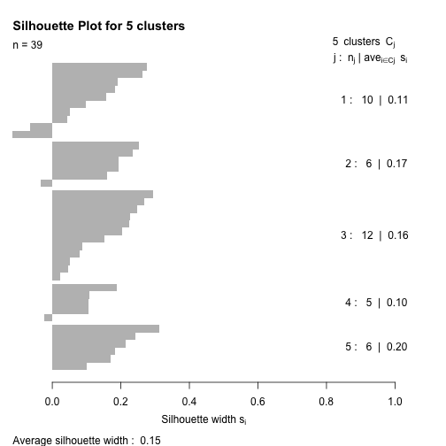

```r
> op <- par(mar = c(5,1,4,4))
> plot(pr.pam, main = "Silhouette Plot for 5 clusters")
```

```r
> par(op)
```

#### Exercise

**Exercise 1:** draw a plot with number of clusters in the x-axis and the average silhouette widths in the y-axis. Use the information obtained to determine if 5 was the best choice for the number of clusters.

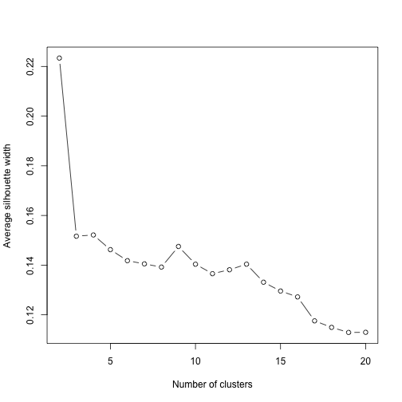

```r
> pamf <- function(ncluster){
+   pr.pam <- pam(pr.dis, k = ncluster)
+   return(pr.pam$silinfo$avg.width)
+ }
> n <- 2:20
> avewid <- rep(NA, 19)
> for (i in 1:19){
+   avewid[i] <- pamf(i+1)
+ }
> plot(avewid ~ n, type="b", xlab="Number of clusters", ylab="Average silhouette width")
```

- 2 is the best choice for the number of cluster.

**Exercise 2:** For a common choice of k, compare the clustering across different methods, e.g. hierarchical (pruned to specific k, obviously), k-means, PAM. You will re-discover the “label switching problem” for yourself. How does that manifest itself? How concordant are the clusterings for different methods?

> k is chosen as 5.

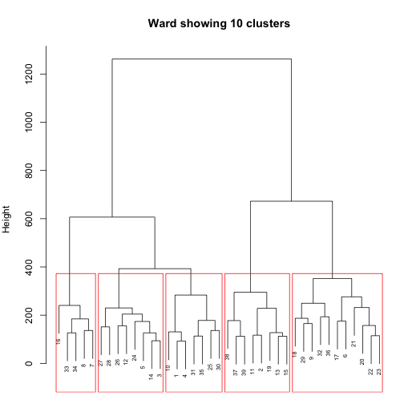

```r
> ### Hierarchical clustering with Ward method
> op <- par(mar = c(1,4,4,1))
> plot(pr.hc.w, labels = prDes$sidNum, cex = 0.6, main = "Ward showing 10 clusters")
> rect.hclust(pr.hc.w, k = 5)
```

```r
> par(op)
```

Comparison among different methods when k=5

|  | Hierarchical_sidNum | kmeans_sidNum | PAM_sidNum |
| --- | --- | --- | --- |
| 1 | 7,8,16,33,34 (5) | 5,7,8,16,26,27,28,33,34 (9) | 7,8,16,28,33,34 (6) |
| 2 | 1,4,10,25,30,31,35 (7) | 1,3,4,10,14,24,25,30,31,35 (10) | 1,3,4,5,12,14,24,25,26,27,31,35 (12) |
| 3 | 3,5,12,14,24,26,27,28 (8) | 18,29,32,36,38 (5) | 32,36,37,38,39 (5) |
| 4 | 2,11,13,15,19,37,38,39 (8) | 2,11,12,13,15,19,37,39 (8) | 2,11,13,15,18,19 (6) |
| 5 | 6,9,17,18,20,21,22,23,29,32,36 (11) | 6,9,17,20,21,22,23 (7) | 6,9,10,17,20,21,22,23,29,30 (10) |

### Gene clustering

In many cases, analysts use cluster analysis to illustrate the results of a differential expression analysis.

#### A smaller dataset

Use different clustering algorithms to cluster the top 972 genes that showed differential expression across the different developmental stage (BH adjusted p value < 10-5).

```r
> DesMat <- model.matrix(~ devStage, prDes)
> Fit <- lmFit(prDat, DesMat)
> EbFit <- eBayes(Fit)
> topHits <- topTable(EbFit, coef = grep("devStage", colnames(coef(EbFit))),
+                     n = Inf, p.value = 1e-05)
> topGenes <- rownames(topHits)
> length(topGenes)
```

```
[1] 972
```

```r
> topDat <- sprDat[topGenes, ]
```

#### Hierarchical

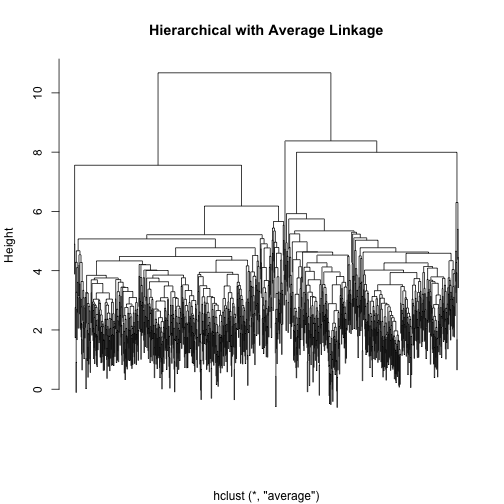

```r
> geneC.dis <- dist(topDat, method = 'euclidean')
> geneC.hc.a <- hclust(geneC.dis, method = 'average')
> plot(geneC.hc.a, labels = FALSE, main = "Hierarchical with Average Linkage", xlab = "")
```

#### Partitioning

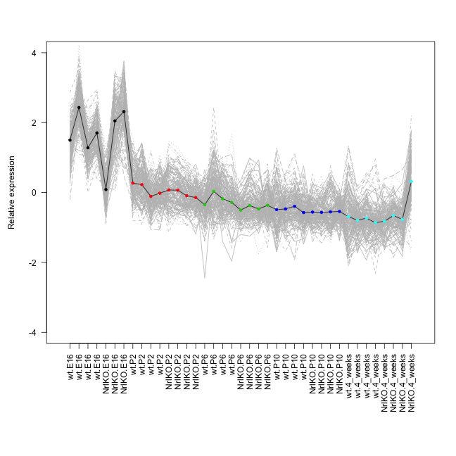

```r
> set.seed(1234)
> k <- 5
> kmeans.genes <- kmeans(topDat, centers = k)
>
> # choose which cluster we want
> clusterNum <- 1
>
> # Set up the axes without plotting; ylim set based on trial run.
> par(oma=c(6, 0.5, 0, 0))
> plot(kmeans.genes$centers[clusterNum, ], xlim = c(0, 40), ylim = c(-4, 4), type = 'n',
+      frame.plot = TRUE, axes = FALSE, xlab = "", ylab = "Relative expression")
>
> # Plot the expression of all the genes in the selected cluster in grey.
> matlines(y = t(topDat[kmeans.genes$cluster == clusterNum, ]), col = 'grey')
>
> # Add the cluster center. This is last so it isn't underneath the members
> points(kmeans.genes$centers[clusterNum, ], type = 'l')
>
> # Optional: colored points to show which development stage the samples are from.
> points(kmeans.genes$centers[clusterNum, ],  col = prDes$devStage, pch = 20)
>
> # add x-axis and y-axis
> axis(side = 1, at = seq(1, 39, 1), labels = prDes$grp, cex.asis = 0.9, las = 2)
> axis(side = 2, at = seq(-4, 4, 2), labels = seq(-4, 4, 2), las = 1)
```

#### Or, probably more commonly used, we can see both dendrograms using heatmaps (through hierarchical clustering):

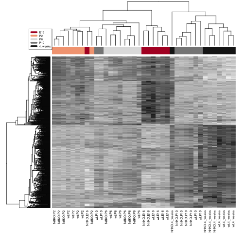

```r
> devStageCols <- brewer.pal(11, "RdGy")[c(2,4,7,9,11)]
> heatmap(as.matrix(topDat), col = jGraysFun(256),
+         hclustfun = function(x) hclust(x, method = 'average'),
+         labCol = prDes$grp, labRow = NA, margin = c(8,1), scale = "none",
+         ColSideColor = devStageCols[unclass(prDes$devStage)])
> legend("topleft", levels(prDes$devStage), col = devStageCols,
+        lty = 1, lwd = 5, cex = 0.5)
```

#### Redefining the attributes

In the previous example, all the samples were used as attributes to cluster genes. However, we can define different attributes, for example, by estimating parameters of a linear model. Consider: \[ \begin{equation} X_{gi,devStage} = \mu_{g,devStage} + \epsilon_{gi,devStage} \end{equation} \] Thus, we can define a new attributes for each gene, i.e., \[Att_g=(\mu_{g,E16},\mu_{g,P2},\mu_{g,P6},\mu_{g,P10},\mu_{g,4w})\] and estimate these parameters.

```r
> annoTopDat <- stack(as.data.frame(topDat)) # stack probe data tall and skinny
> annoTopDat$probeset <- rownames(topDat) # add probeset ID as variable
> ## get info on gType and devStage, then average over reps within devStage
> annoTopDat <- merge(annoTopDat, prDes, by.x = "ind", by.y = "sidChar")
> devStageAvg <- ddply(annoTopDat, ~ probeset, function(x) {
+   avgByDevStage <- aggregate(values ~ devStage, x, mean)$values
+   names(avgByDevStage) <- levels(x$devStage)
+   avgByDevStage
+   })
> ## put probset info back into rownames
> rownames(devStageAvg) <- devStageAvg$probeset
> devStageAvg$probeset <- NULL
> str(devStageAvg)
```

```
'data.frame':   972 obs. of  5 variables:
 $ E16    : num  -0.628 1.235 -0.419 1.401 0.855 ...
 $ P2     : num  -1.041 0.7 -0.918 0.737 0.74 ...
 $ P6     : num  -0.214 -0.26 -0.744 -0.66 0.34 ...
 $ P10    : num  0.722 -0.683 0.553 -0.779 -0.363 ...
 $ 4_weeks: num  1.083 -0.838 1.475 -0.523 -1.464 ...
```

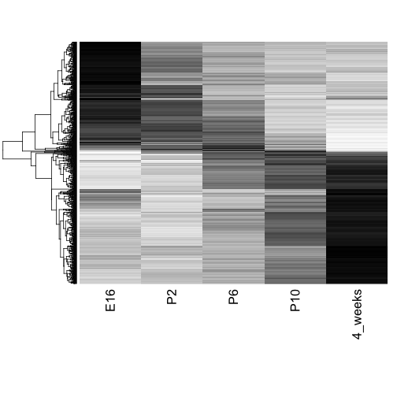

```r
> heatmap(as.matrix(devStageAvg), Colv = NA, col = jGraysFun(256),
+         hclustfun = function(x) hclust(x,method = 'average'),
+         labCol = colnames(devStageAvg), labRow = NA, margin = c(8,1))
```

Look at the average expression of genes within a cluster for each developmental stage.

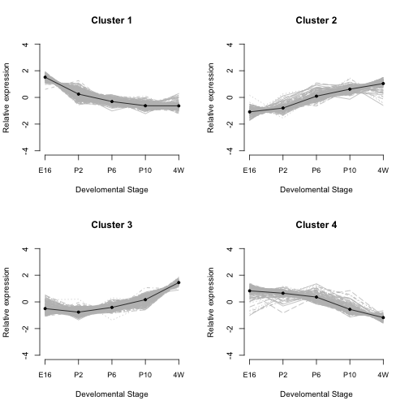

```r
> k <- 4
> geneDS.km <- kmeans(devStageAvg, centers = k, nstart = 50)
> clust.centers <- geneDS.km$centers
>
> #Look at all clusters
> op <- par(mfrow = c(2, 2))
> for(clusterNum in 1:4) {
+   # Set up the axes without plotting; ylim set based on trial run.
+   plot(clust.centers[clusterNum,], ylim = c(-4,4), type='n',
+        xlab = "Develomental Stage", ylab = "Relative expression",
+        axes = F, main = paste("Cluster", clusterNum, sep = " "))
+   axis(2)
+   axis(1, 1:5, c(colnames(clust.centers)[1:4],"4W"), cex.axis = 0.9)
+
+   # Plot the expression of all the genes in the selected cluster in grey.
+   matlines(y = t(devStageAvg[geneDS.km$cluster == clusterNum, ]),
+            col = 'grey')
+
+   # Add the cluster center. This is last so it isn't underneath the members
+   points(clust.centers[clusterNum, ] , type = 'l')
+
+   # Optional: points to show development stages.
+   points(clust.centers[clusterNum, ],  pch = 20)
+   }
```

```r
> par(op)
```

Compare all clusters' centers.

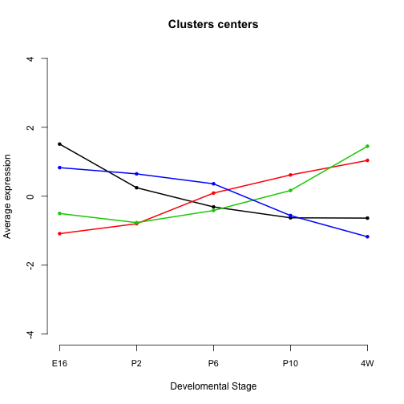

```r
> plot(clust.centers[clusterNum, ], ylim = c(-4, 4), type = 'n',
+      xlab = "Develomental Stage", ylab = "Average expression",
+      axes = FALSE, main = "Clusters centers")
> axis(2)
> axis(1, 1:5, c(colnames(clust.centers)[1:4],"4W"), cex.axis = 0.9)
>
> for(clusterNum in 1:4) {
+   points(clust.centers[clusterNum,], type = 'l', col = clusterNum, lwd=2)
+   points(clust.centers[clusterNum,] , col = clusterNum, pch = 20)
+   }
```

We can look at 3-dimensions of the data and illustrate clusters determined by kmeans. The most interesting analysis is to follow with a biological interpretation of the clusters. For that, smaller clusters may be easier to interpret.

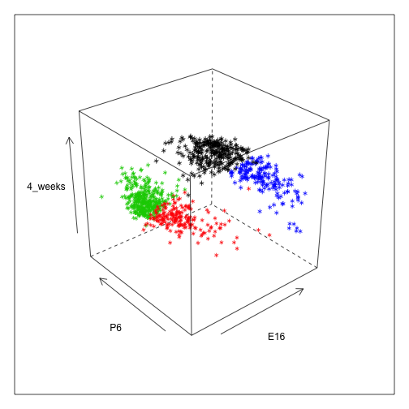

```r
> cloud(devStageAvg[ ,"E16"] ~ devStageAvg[ ,"P6"] * devStageAvg[ ,"4_weeks"],
+       col = geneDS.km$clust, xlab = "E16", ylab = "P6", zlab = "4_weeks")
```

### Statistical measures to evaluate clusters

An important issue for clustering is the question of certainty of the cluster membership. Clustering always gives you an answer, even if there aren't really any underlying clusters. There are many ways to address this. Here we introduce an approachable one offered in R, `pvclust`.

```r
> pvc <- pvclust(topDat, nboot = 100)
```

```
Bootstrap (r = 0.5)... Done.
Bootstrap (r = 0.6)... Done.
Bootstrap (r = 0.7)... Done.
Bootstrap (r = 0.8)... Done.
Bootstrap (r = 0.9)... Done.
Bootstrap (r = 1.0)... Done.
Bootstrap (r = 1.1)... Done.
Bootstrap (r = 1.2)... Done.
Bootstrap (r = 1.3)... Done.
Bootstrap (r = 1.4)... Done.
```

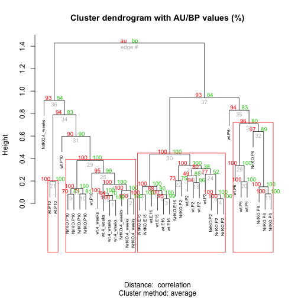

```r
> plot(pvc, labels = prDes$grp, cex = 0.6)
> pvrect(pvc, alpha = 0.95)
```

### PCA (principal components analysis)

In R, we can use `prcomp()` to do PCA. You can also use `svd()`.

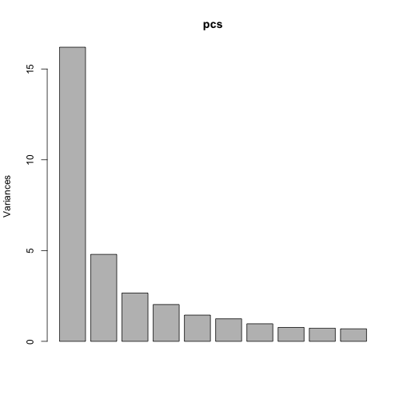

```r
> pcs <- prcomp(sprDat, center = F, scale = F)
>
> # scree plot
> plot(pcs)
```

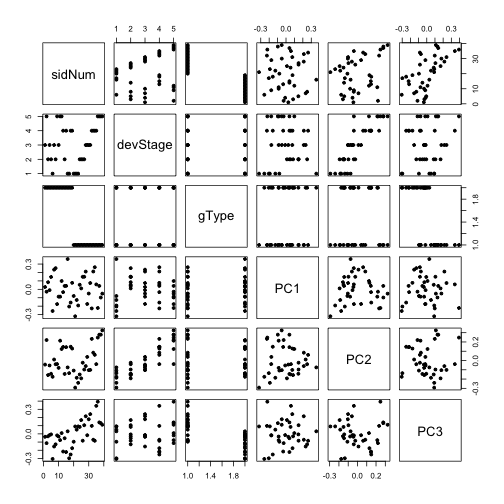

```r
>
> # append the rotations for the first 10 PCs to the phenodata
> prinComp <- cbind(prDes, pcs$rotation[prDes$sidChar, 1:10])
>
> # scatter plot showing us how the first few PCs relate to covariates
> plot(prinComp[ ,c("sidNum", "devStage", "gType", "PC1", "PC2", "PC3")],
+      pch = 19, cex = 0.8)
```

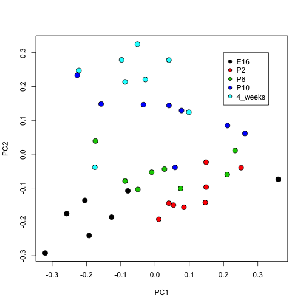

```r
>
> # plot data on first two PCs, colored by development stage
> plot(prinComp[ ,c("PC1","PC2")], bg = prDes$devStage, pch = 21, cex = 1.5)
> legend(list(x = 0.2, y = 0.3), as.character(levels(prDes$devStage)),
+        pch = 21, pt.bg = c(1,2,3,4,5))
```

> This is the end of seminar09.